# P2

Se va calcular la media o “mu”:

```r
mu_Cos<-mean(DFNN$CostoSeguro)
mu_Cos
```

```
## [1] 340.7291
```

El valor de “mu” es: 340.7291

También se va calcular la desviación estándar:

```r
sd_COs<-sd(DFNN$CostoSeguro)
sd_COs
```

```
## [1] 227.0933
```

El valor de la desviación estándar es: 227.0933

Con los datos obtenidos se va graficar la función normal en el histograma de densidad anterior.

```r
x<- DFNN$CostoSeguro
```

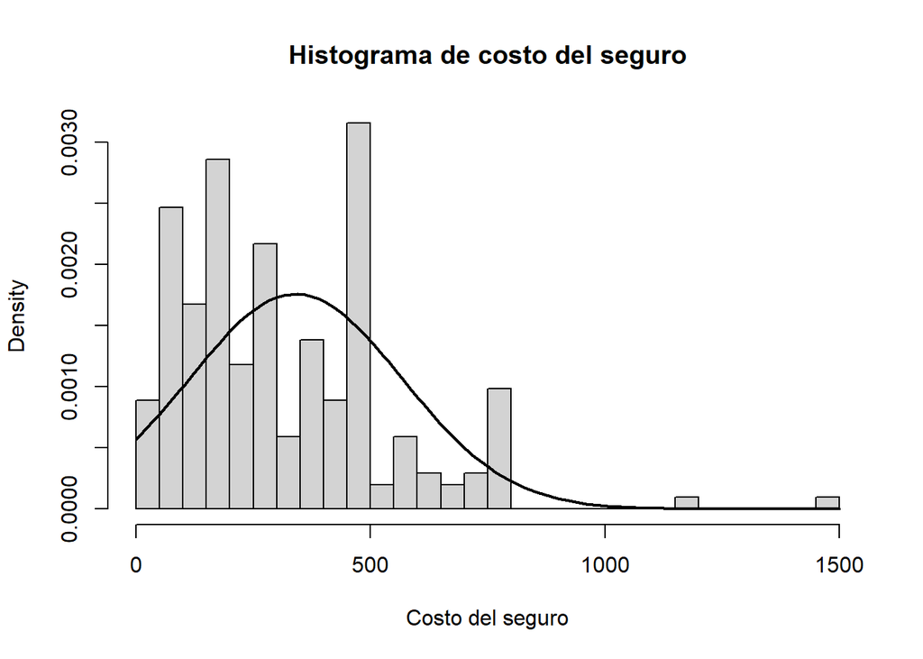

```r
hist(DFNN$CostoSeguro,probability = 1,main = "Histograma de costo del seguro",xlab = "Costo del seguro", breaks = 40)
curve(dnorm(x,mu_Cos,sd_COs),lwd=2,add=T)
```

En la gráfica podemos evidenciar que la función normal esta distribuida principalmente en costos menor a 1000 soles.

En una fuente respecto al precio de los seguros privados menciona que estos oscilan entre 100 a 700 soles. En el caso nuestro se va calcular la probabilidad de que ello suceda, para lo cual nos planteaos la siguiente pregunta: ¿Cuál es la probabilidad de que el costo del seguro este entre 100 a 700 soles? La función probabilidad sería P(100<X<700) el cálculo seria P(X<700) - P(X<100)

```r
pnorm(700,mu_Cos,sd_COs)-pnorm(100,mu_Cos,sd_COs)
```

```
## [1] 0.7986178
```

La probabilidad de que suceda es de 0.7986178. Ese dato lo podemos corroborar con la gráfica, puesto puesto que el área de la función se ve que es más grande en ese rango.

Interacción entre variables

En este caso se va relacionar la probabilidad de que una persona desee cambiarse de seguro, ello respecto a a cada seguro.

Para ello vamos a realizar una tabla con las probabilidades

```r
probSeguroscondicionado<-prop.table(table(DFNN$NombreSeguro,DFNN$CambioDeSeguro))
probSeguroscondicionado
```

```
##
##                        No          Si
##   BCP         0.093596059 0.039408867
##   Crediscotia 0.009852217 0.014778325
##   Interbank   0.009852217 0.019704433
##   La Positiva 0.044334975 0.024630542
##   Mapfre      0.049261084 0.024630542
##   Oncosalud   0.152709360 0.128078818
##   Pacífico    0.083743842 0.044334975
##   Rimac       0.113300493 0.098522167
##   Sanitas     0.024630542 0.004926108
##   Scotiabank  0.014778325 0.004926108
```

En la tabla podemos evidenciar la probabilidad de que una persona quiera cambiar o continuar en su seguro, ello se hizo respecto a toda la data, puesto que la suma de las probabilidades es igual a 1.

Para ello podemos plantearnos casos de aplicación, en este caso va ser respecto al seguro más usado en nuestra muestra, el cual es Oncosalud:

¿Cuál es la probabilidad de que se necesite encuestar a 10 personas, de los cuales 4 quieran cambiarse del seguro Oncosalud?

Podemos evidenciar que el modelo es de tipo binomial negativa o pascal. La probabilidad sería:

P(X=10) El número de éxitos k -> 4

Al ser pascal se va calcular el numero de fracasos: X=Y+k Y=6 P(Y=6) La probabilidad de que quieran cambiarse del seguro Oncosalud es 0.128078818, aplicando en el modelo:

```r
dnbinom(6,4,0.128078818)
```

```
## [1] 0.009932347
```

Se obtiene la probabilidad de 0.009932347

Se va graficar la forma que siga modelo binomial negativo, donde el número de éxitos que consideremos va ser igual a 4, según nuestra pregunta.

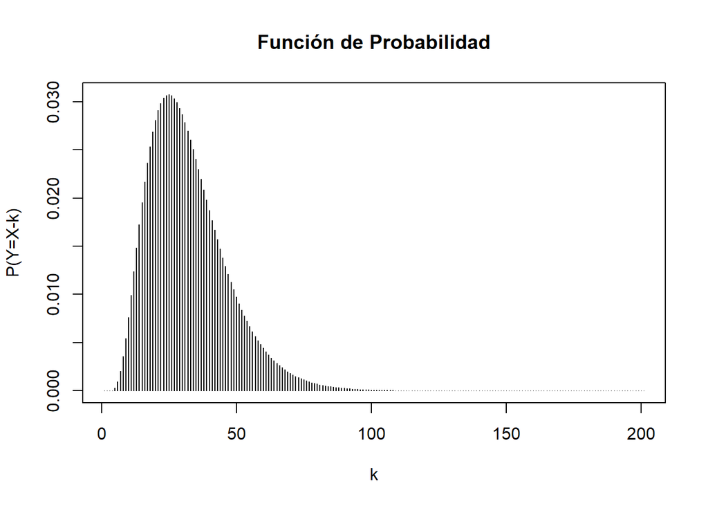

```r
plot(dnbinom((0:200)-4,4,0.128078818),type="h",xlab="k",ylab="P(Y=X-k)",main="Función de Probabilidad")
```

En la gráfica podemos evidenciar que la probabilidad es mayor entre el rango de 4 a 110 aproximadamente, también se puede aclarar que para personas a 4 la probabilidad sería 0, puesto que no se podría obtener los 4 éxitos.

### **Bibliografía**

Comparabien. (2021, julio 3). ¿Cuánto cuesta un seguro privado de salud en Perú? Comparabien. https://comparabien.com.pe/blog-consejos/cuanto-cuesta-seguro-privado-salud-peru

Peruano, E. E. (22d. C., agosto 5). Seguros de salud del Perú. Gob.pe. https://www.gob.pe/281-seguros-de-salud-del-peru

Superintendencia de Banca, S. y. A. del P. (s/f). Seguros privados de salud: ¿Cómo operan y qué hay que considerar al momento de contratar una cobertura? SBSPerú. Recuperado el 24 de junio de 2022, de https://www.sbs.gob.pe/boletin/detalleboletin/idbulletin/72